# Finish Aligning and Generate Read Counts

Yujin Choi

2023-04-02

# Github Repository

Link to my GitHub Repo is [here](https://github.com/laurelis/ANGSD-Final).

# Align Samples

Script for downloading all remaining samples and the script will `STAR` align each sample to the indexed reference genome.

```r
#!/bin/bash -l
#SBATCH --partition=angsd_class
#SBATCH --nodes=1
#SBATCH --ntasks=1
#SBATCH --job-name="download-align"
#SBATCH --time=10:0:00 # HH/MM/SS
#SBATCH --mem=40G # memory requested, units available: K,M,G,T
#SBATCH --mail-user=yuc4017@med.cornell.edu
#SBATCH --mail-type=ALL
#SBATCH --requeue
#SBATCH --output=/home/yuc4017/slurm/slurm-%j.out

IFS=" "
SRR_IDS=$(cat SRR_accession_IDs.txt)
read -a SRR_IDS <<< $(cat SRR_accession_IDs.txt)

mamba activate angsd

for ID in "${SRR_IDS[@]}"; do
    echo "==================================="
    echo "Now downloading sample ${ID}"
    if [ ! -r  /athena/angsd/scratch/yuc4017/fastq/${ID}.fastq.gz ]; then
        url="ftp://ftp.sra.ebi.ac.uk/vol1/fastq/SRR709/00${ID: -1}/${ID}/${ID}.fastq.gz"
        echo $url
        curl -L $url -o /athena/angsd/scratch/yuc4017/fastq/${ID}.fastq.gz
    fi
done

for file in /athena/angsd/scratch/yuc4017/fastq/*.fastq.gz; do
    echo "==================================="
    ID=`echo $file | egrep -o 'SRR[0-9]*'`
    echo "FastQC on ${ID}"
    if [ ! -r  /athena/angsd/scratch/yuc4017/fastqc/${ID}_fastqc.html ]; then
        fastqc -o /athena/angsd/scratch/yuc4017/fastqc/ "$file" --extract;
        echo  "/athena/angsd/scratch/yuc4017/fastqc/${ID}_fastqc.html"
    fi
    echo "==================================="
    echo "Alignment on ${ID}"
    if [ ! -r  /athena/angsd/scratch/yuc4017/alignments/${ID}.Log.final.out ]; then
                STAR --runMode alignReads \
            --runThreadN 1 \
            --genomeDir /athena/angsd/scratch/yuc4017/genome/index \
            --readFilesIn /athena/angsd/scratch/yuc4017/fastq/${ID}.fastq.gz \
            --readFilesCommand zcat \
            --outFileNamePrefix /athena/angsd/scratch/yuc4017/alignments/${ID}. \
            --outSAMtype BAM SortedByCoordinate

        samtools index /athena/angsd/scratch/yuc4017/alignments/${ID}.Aligned.sortedByCoord.out.bam
                echo  "/athena/angsd/scratch/yuc4017/alignments/${ID}.Aligned.sortedByCoord.out.bam.bai"
        fi
done
```

# QorTs and RseQC

```r
#!/bin/bash -l
#SBATCH --partition=angsd_class
#SBATCH --nodes=1
#SBATCH --ntasks=1
#SBATCH --job-name="qorts"
#SBATCH --time=24:0:00 # HH/MM/SS
#SBATCH --mem=40G # memory requested, units available: K,M,G,T
#SBATCH --mail-user=yuc4017@med.cornell.edu
#SBATCH --mail-type=ALL
#SBATCH --requeue
#SBATCH --output=/home/yuc4017/slurm/slurm-%j.out

mamba activate qorts

for SAMPLE in /athena/angsd/scratch/yuc4017/alignments/*.bam; do

    ID=`echo $SAMPLE | egrep -o 'SRR[0-9]*'`
    qorts -Xmx18G QC --singleEnded --stranded --generatePlots ${SAMPLE} /athena/angsd/scratch/yuc4017/genome/Homo_sapiens.GRCh38.109.gtf /athena/angsd/scratch/yuc4017/qorts/${ID}/

done
```

Download hg38 `BED` file from [UCSC annotation track database](https://genome.ucsc.edu/cgi-bin/hgTables), then remove the `chr` on the chromosome labels to be compatible with Ensembl aligned reads.

`sed "s/^chr//" /athena/angsd/scratch/yuc4017/hg38.bed > /athena/angsd/scratch/yuc4017/hg3 8.nochr.bed`

Then, ran samples through `rseqc`.

```r
#!/bin/bash -l
#SBATCH --partition=angsd_class
#SBATCH --nodes=1
#SBATCH --ntasks=1
#SBATCH --job-name="rseqc"
#SBATCH --time=10:0:00 # HH/MM/SS
#SBATCH --mem=40G # memory requested, units available: K,M,G,T
#SBATCH --mail-user=yuc4017@med.cornell.edu
#SBATCH --mail-type=ALL
#SBATCH --requeue
#SBATCH --output=/home/yuc4017/slurm/slurm-%j.out


mamba activate rseqc

for SAMPLE in /athena/angsd/scratch/yuc4017/alignments/*.bam; do

  ID=`echo $SAMPLE | egrep -o 'SRR[0-9]*'`

    geneBody_coverage.py -i ${SAMPLE} -r /athena/angsd/scratch/yuc4017/hg38.nochr.bed -o /athena/angsd/scratch/yuc4017/rseqc/${ID}.rseqc_geneBody_coverage.out
    read_distribution.py -i ${SAMPLE} -r /athena/angsd/scratch/yuc4017/hg38.nochr.bed > /athena/angsd/scratch/yuc4017/rseqc/${ID}.rseqc_read_distribution.out

done
```

# MultiQC

```r
#!/bin/bash -l
#SBATCH --partition=angsd_class
#SBATCH --nodes=1
#SBATCH --ntasks=1
#SBATCH --job-name="multiqc"
#SBATCH --time=10:0:00 # HH/MM/SS
#SBATCH --mem=40G # memory requested, units available: K,M,G,T
#SBATCH --mail-user=yuc4017@med.cornell.edu
#SBATCH --mail-type=ALL
#SBATCH --requeue
#SBATCH --output=/home/yuc4017/slurm/slurm-%j.out

mamba activate multiqc

multiqc -o /athena/angsd/scratch/yuc4017/multiqc/all_qc/ /athena/angsd/scratch/yuc4017/
```

# Generate Count Table and Analyze

```r
#!/bin/bash -l
#SBATCH --partition=angsd_class
#SBATCH --nodes=1#SBATCH --ntasks=1
#SBATCH --job-name="featurecounts"
#SBATCH --time=7:0:00 # HH/MM/SS
#SBATCH --mem=35G # memory requested, units available: K,M,G,T
#SBATCH --mail-user=yuc4017@med.cornell.edu
#SBATCH --mail-type=ALL
#SBATCH --requeue
#SBATCH --output=/home/yuc4017/slurm/slurm-%j.out

mamba activate angsd

featureCounts -M --minOverlap 1 -a /athena/angsd/scratch/yuc4017/genome/Homo_sapiens.GRCh38.109.gtf -o featureCounts.txt /athena/angsd/scratch/yuc4017/alignments/*.bam
```

```r
library(tidyverse)
library(reshape2)
library(patchwork)
library(RColorBrewer)

toc = read.table('SRA-to-Condition.txt',sep='\t')
toc
```

| V1 | V2 |
| --- | --- |
| SRR7093809 | young |
| SRR7093874 | young |
| SRR7093875 | young |
| SRR7093876 | young |
| SRR7093877 | young |
| SRR7093878 | young |
| SRR7093879 | young |
| SRR7093880 | young |
| SRR7093881 | young |
| SRR7093882 | young |

[output cut: 20 more lines]

```r
count_data <- data.table::fread(text="featureCounts.txt.summary", header=TRUE) %>% as.data.frame
orig_names <- names(count_data)

names(count_data) <- gsub(".*(SRR[0-9]+).*", "\\1", orig_names)

count_data <- count_data[rowSums(count_data[,-1])>0,]
count_data <- melt(count_data, value.name = "num_reads", variable.name= "sample")

conditions <- c()
for (i in 1:nrow(count_data)){
  conditions <- append(conditions, toc[toc[,1] == count_data[i,"sample"],][,2])
}

count_data$condition <- conditions
count_data
```

| Status | sample | num_reads | condition |
| --- | --- | --- | --- |
| Assigned | SRR7093809 | 21523140 | young |
| Unassigned_NoFeatures | SRR7093809 | 1989478 | young |
| Unassigned_Ambiguity | SRR7093809 | 1951233 | young |
| Assigned | SRR7093851 | 17530651 | old |
| Unassigned_NoFeatures | SRR7093851 | 1339421 | old |
| Unassigned_Ambiguity | SRR7093851 | 1531558 | old |
| Assigned | SRR7093852 | 18931436 | old |
| Unassigned_NoFeatures | SRR7093852 | 1480136 | old |
| Unassigned_Ambiguity | SRR7093852 | 1699782 | old |
| Assigned | SRR7093853 | 16039531 | old |

[output cut: 80 more lines]

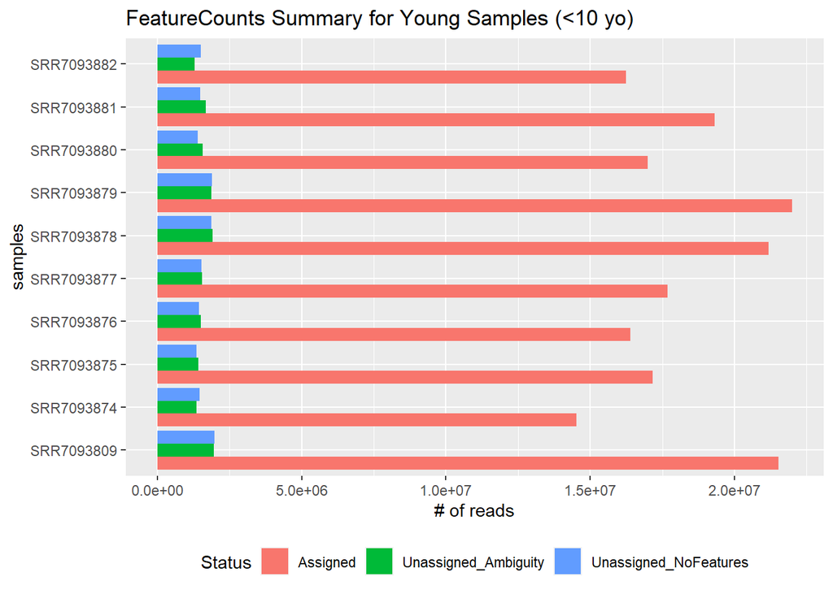

```r
#Visualize Assigned vs Unassigned Count for Each Condition
p_young <- ggplot(count_data[count_data$condition=="young",], aes(fill=Status, y=sample, x=num_reads)) +
    geom_bar(position="dodge", stat="identity") +
    theme(legend.position="bottom")
p_young <- p_young + labs(x="# of reads",
              y="samples",
              title="FeatureCounts Summary for Young Samples (<10 yo)")
p_young
```

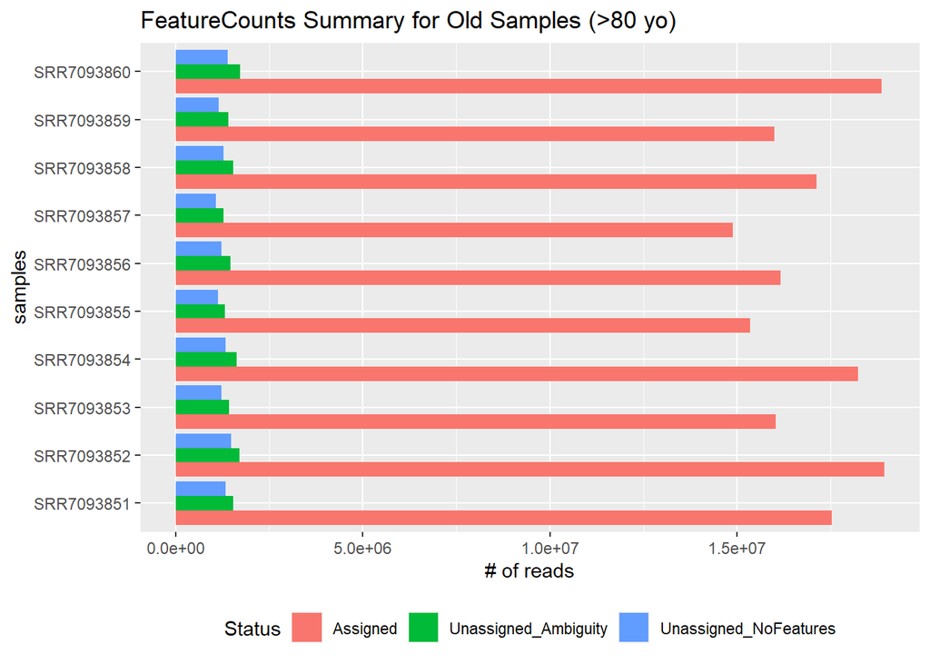

```r
p_old <- ggplot(count_data[count_data$condition=="old",], aes(fill=Status, y=sample, x=num_reads)) +
    geom_bar(position="dodge", stat="identity") +
    theme(legend.position="bottom")
p_old <- p_old + labs(x="# of reads",
              y="samples",
              title="FeatureCounts Summary for Old Samples (>80 yo)")
p_old
```

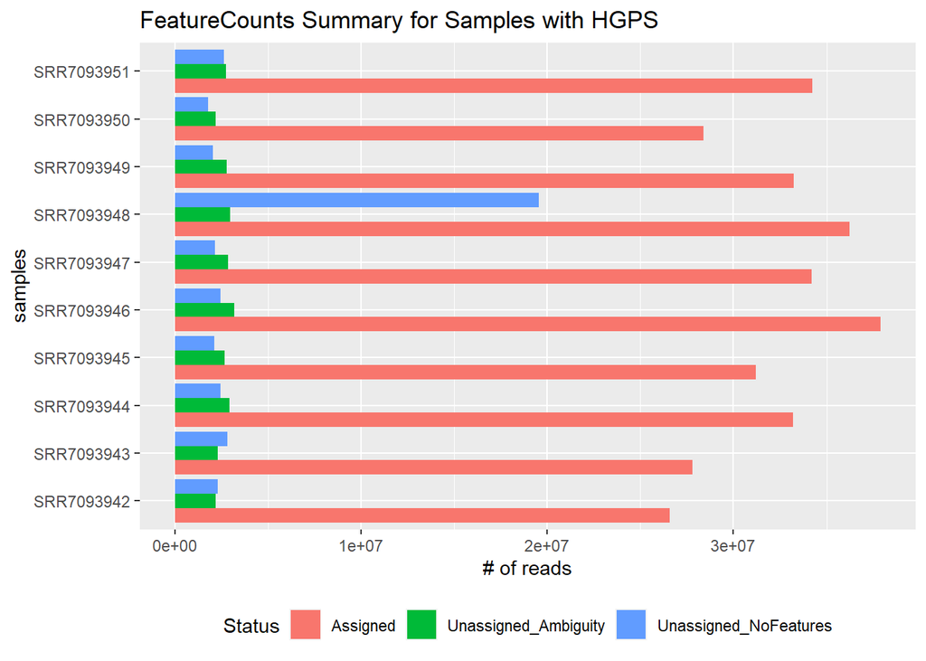

```r
p_hgps <- ggplot(count_data[count_data$condition=="hgps",], aes(fill=Status, y=sample, x=num_reads)) +
    geom_bar(position="dodge", stat="identity") +
    theme(legend.position="bottom")
p_hgps <- p_hgps + labs(x="# of reads",
              y="samples",
              title="FeatureCounts Summary for Samples with HGPS")
p_hgps
```

There seems to be a strangely high number of un-assigned features in one of the HGPS samples `SRR7093948`. I’m not certain whether this is due to a mistake during featureCounts or if the sample itself has unusual reads (note: it was not abnormal in the FastQC tests).

# DESeq Analysis

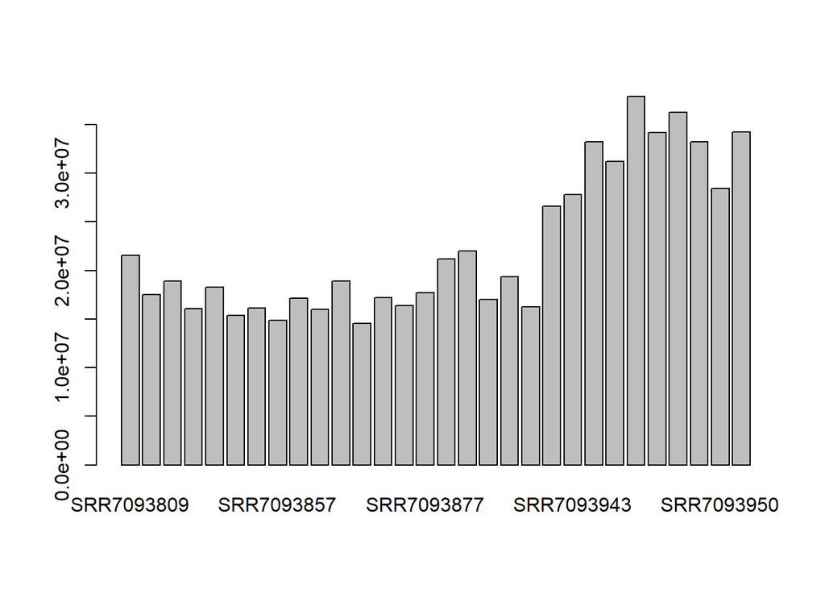

```r
library(DESeq2)
library(goseq)
library(magrittr)
library(tidyverse)
library(TxDb.Scerevisiae.UCSC.sacCer3.sgdGene)
library(org.Sc.sgd.db)
library("pheatmap")
library("RColorBrewer")

fc_data <- data.table::fread(text="featureCounts.txt", header=TRUE) %>% as.data.frame

orig_names <- names(fc_data)

names(fc_data) <- gsub(".*(SRR[0-9]+).*", "\\1", orig_names)
fc_data_counts <- fc_data[,grepl("SRR", names(fc_data))] %>% dplyr::select(sort(names(.)))
row.names(fc_data_counts)=fc_data$Geneid

toc2 <- toc
rownames(toc2) <- toc2[,1]
toc2[,1] <- NULL
colnames(toc2) <- c("condition")
sample_info <- data.frame(toc2)
sample_info <- sample_info[sort(rownames(sample_info)), ,drop=F]

#make DESeq object from feature Counts
DESeq.ds <- DESeqDataSetFromMatrix(countData=fc_data_counts, colData=sample_info, design=~condition)
rownames(DESeq.ds) <- fc_data$Geneid
keep_genes <- rowSums(counts(DESeq.ds)) > 0
DESeq.ds <- DESeq.ds[ keep_genes, ]
DESeq.ds$condition %<>% relevel(ref="young")

colSums(counts(DESeq.ds)) %>% barplot
```

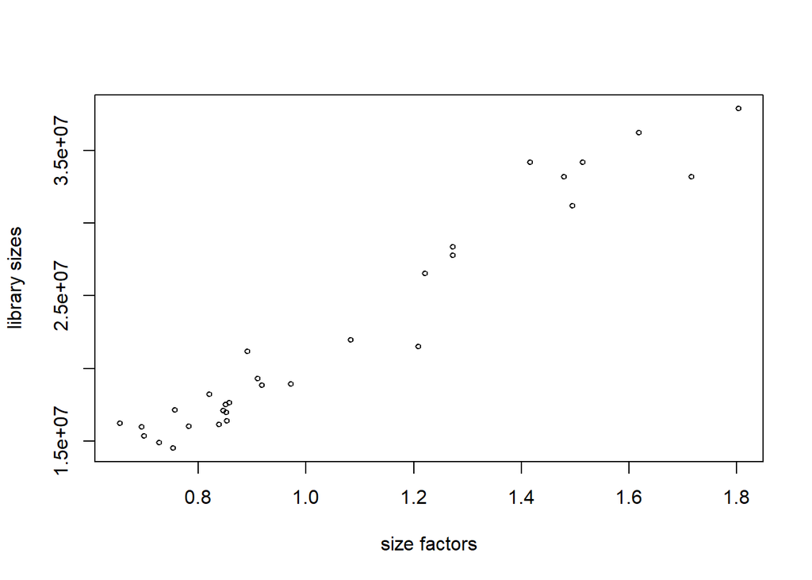

```r
#estimate Size Factors and Normalize Data
DESeq.ds <- estimateSizeFactors(DESeq.ds)
plot( sizeFactors(DESeq.ds), colSums(counts(DESeq.ds)), ylab = "library sizes", xlab = "size factors", cex = .6 )
```

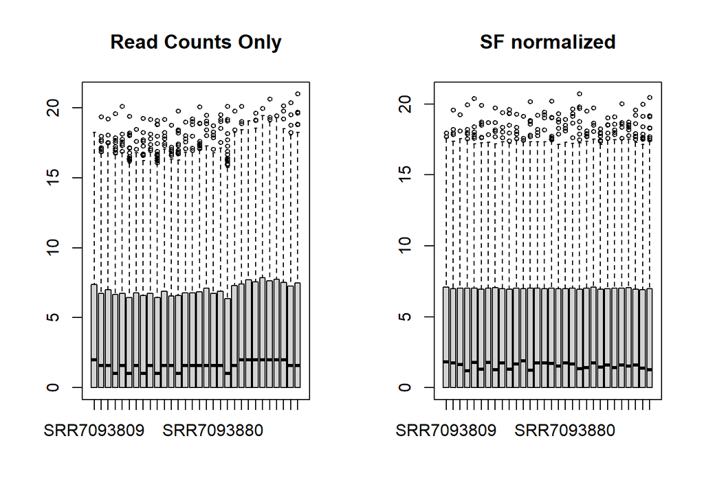

```r
assay(DESeq.ds, "log.counts") <- log2(counts(DESeq.ds, normalized = FALSE) + 1)
assay(DESeq.ds, "log.norm.counts") <- log2(counts(DESeq.ds, normalized=TRUE) + 1)

par(mfrow=c(1,2))
counts.sf_normalized <- counts(DESeq.ds, normalized=TRUE)
boxplot(assay(DESeq.ds, "log.counts"), main = "Read Counts Only", cex = .6)
boxplot(assay(DESeq.ds, "log.norm.counts"), main = "SF normalized", cex = .6)
```

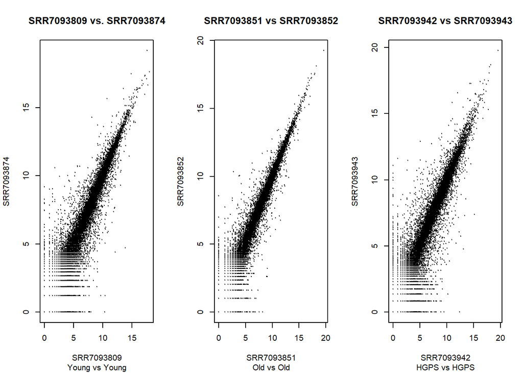

```r
#rlog Transform

DESeq.rlog <- rlog(DESeq.ds, blind = TRUE)

par(mfrow=c(1,3))
DESeq.ds[, c("SRR7093809","SRR7093874")] %>%
  assay(., "log.norm.counts") %>%
  plot(., cex=.1, main = "SRR7093809 vs. SRR7093874", sub="Young vs Young")

DESeq.ds[, c("SRR7093851","SRR7093852")] %>%
assay(., "log.norm.counts") %>%
plot(., cex=.1, main = "SRR7093851 vs SRR7093852", sub="Old vs Old")

DESeq.ds[, c("SRR7093942","SRR7093943")] %>%
assay(., "log.norm.counts") %>%
plot(., cex=.1, main = "SRR7093942 vs SRR7093943", sub="HGPS vs HGPS")
```

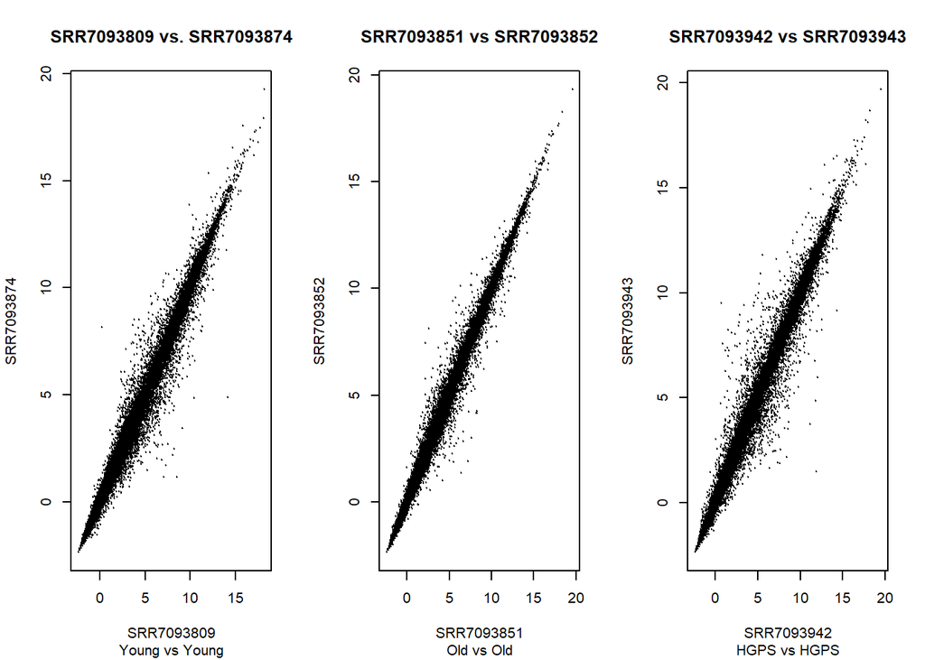

```r
par(mfrow=c(1,3))
DESeq.rlog[, c("SRR7093809","SRR7093874")] %>%
  assay(.) %>%
  plot(., cex=.1, main = "SRR7093809 vs. SRR7093874", sub="Young vs Young")

DESeq.rlog[, c("SRR7093851","SRR7093852")] %>%
assay(.) %>%
plot(., cex=.1, main = "SRR7093851 vs SRR7093852", sub="Old vs Old")

DESeq.rlog[, c("SRR7093942","SRR7093943")] %>%
assay(.) %>%
plot(., cex=.1, main = "SRR7093942 vs SRR7093943", sub="HGPS vs HGPS")
```

# Sample-to-Sample Clustering (Heatmap)

HGPS samples seem to cluster together but young and old samples do not.

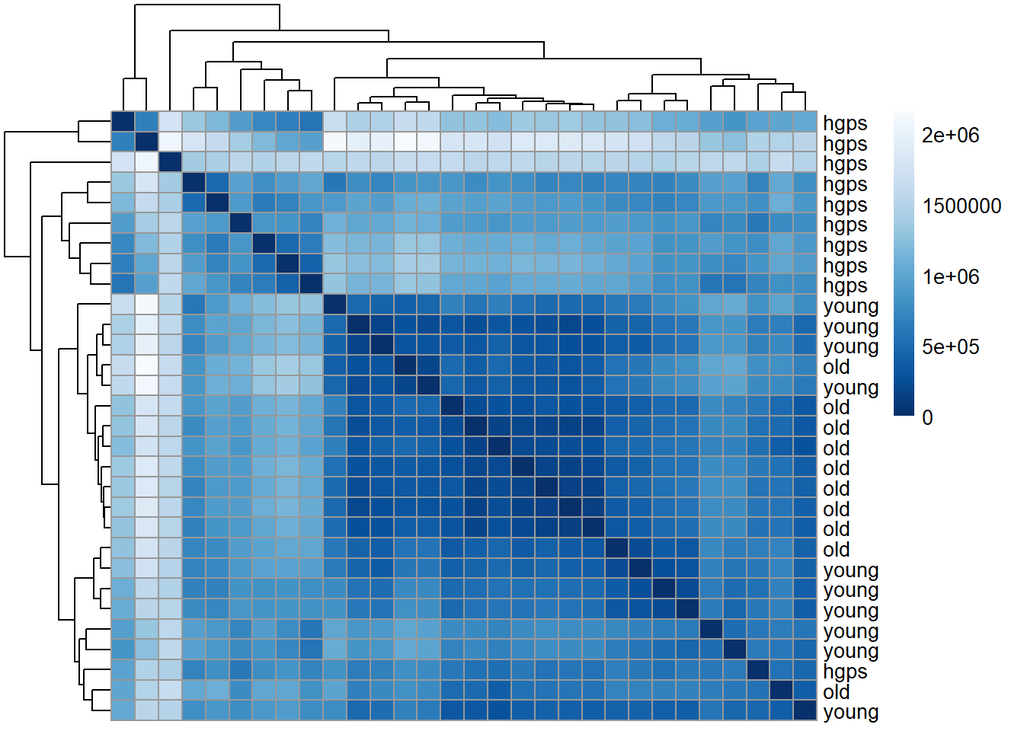

```r
#heatmap
sampleDists <- dist(t(assay(DESeq.ds)))

sampleDistMatrix <- as.matrix(sampleDists)
rownames(sampleDistMatrix) <- paste(DESeq.ds$condition, sep="-")
colnames(sampleDistMatrix) <- NULL
colors <- colorRampPalette( rev(brewer.pal(9, "Blues")) )(255)
pheatmap(sampleDistMatrix,
         clustering_distance_rows=sampleDists,
         clustering_distance_cols=sampleDists,
         col=colors)
```

# PCA Analysis

PCA seems to group the conditions relatively well; however, one of the “young” samples seems to lie outside of its conditional group.

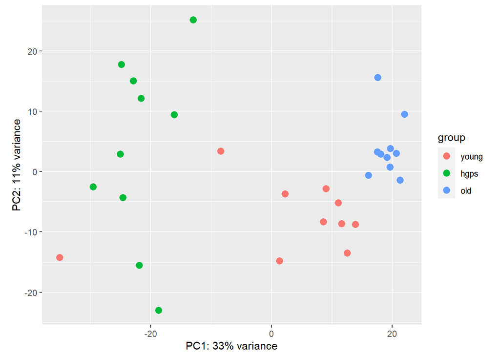

```r
plotPCA(rlog(DESeq.ds), intgroup=c("condition"))
```

# GO Term Enrichment

Started on GO Term Enrichment analysis but did not complete. Only found all of the names of all the differentially expressed genes.

```r
library(TxDb.Hsapiens.UCSC.hg38.knownGene)
library(org.Hs.eg.db)

DESeq.ds <- DESeq(DESeq.ds)
DGE.results <- results(DESeq.ds,independentFiltering = TRUE, alpha=0.05)
DGE.genes <- rownames(subset(DGE.results, padj < 0.05))
head(DGE.genes)
```

```
## [1] "ENSG00000142611" "ENSG00000116786" "ENSG00000162511" "ENSG00000090020"
## [5] "ENSG00000116138" "ENSG00000028137"
```

```r
# gene.vector <- row.names(DGE.results) %in% DGE.genes %>% as.integer
# names(gene.vector) <- row.names(DGE.results)
# pwf <- nullp(gene.vector, "hg38", "ensGene")
#
# plot(pwf$bias.data, pwf$pwf, xlab="Biased Data", ylab="Proportion DE")
```